# ECO 395M exercise 3

Minjin Kang, Paul Park

2023-02-27

## 1) What causes what?

Podcast notetaking

Charlie: Teaching policy in Univ of Chicago and thinking of sending daughter Chicago public school. Mom thought Public school in Chicago is not good.

Charlie made argument with mom : what causes what?

Correlation and causation in decisions When woman ages, estrogen going down and people getting estrogen therapy to solve this problem and it figured out that this therapy - lowering heart disease! With this, people came up with idea that “let’s give estrogen to reduce heart disease” But there can exist other factors: what if people going hospital and getting estrogen is healthier people compare to others who not going hospital? (=selection bias) They did randomized trial Randomly assigned people to one of the group(control/treatment) !!Experiment result!! Women who getting estrogen having higher risk of heart disease(attack/strock) : estrogen is actually bad for heart This is everywhere. it’s correlation, not causation. Statistic is amazing at finding causation but statistic itself is not enough for figuring out causation.

Cops and crime? will high cops lead to low crime? When terrorism alert goes to orange then extra cops will be on the mall etc to protect people Orange alert goes up then street crime goes down Causal relationship at least in Washington DC high cops lead to low crime but isn’t it because less people on the street(num of victim) from terrorism alert?

Yale, IVY league will make kid’s life better? problem: people not randomly assigned to ACC and Harvard, highly talented people go to Harvard. Wage/income comparison is hard here. Hard to study value added to this prestigious school. Large group of student going IVY league/Large group of student going ACC. 10-15 years later they compared. No real huge statistically significant different between income.

Charlie convinced mom about Chicago Public School ____________________________

** Question 1 ** Why I can’t just get data from a few different cities and run the regression of “crime” on “police” to understand how more cops in the streets affect crime?

Running regression is not enough to find causation. The number of cops can’t explain all about the crime rate. There can be other factors(confounders) affecting the crime rate, for example, drug/alcohol regulations, access to weapons, the criminal justice system, income inequality, and population density. Plus, there exist inherent differences for each city, and there can be a selection bias problem from collecting different cities in the sample. If there’s a selection bias problem, we can’t generalize the result of the regression.

## 2) Tree modeling: dengue cases

** CART to predict dengue cases **

```
## [1] 393
```

```
## [1] 0
```

```
## n= 993
##
## node), split, n, deviance, yval
##       * denotes terminal node
##
##    1) root 993 881259.90000 20.784490
##      2) city=iq 399  49707.73000  7.839599
##        4) season=spring,winter 210   3594.66700  4.333333
##          8) specific_humidity< 17.73143 152   1808.81600  3.355263
##           16) precipitation_amt< 90.875 131   1201.23700  3.076336
##             32) precipitation_amt>=48.655 58    403.58620  2.275862
##               64) precipitation_amt< 54.62 12     26.91667  1.083333 *
##               65) precipitation_amt>=54.62 46    355.15220  2.586957
##                130) specific_humidity>=16.69286 27    219.40740  1.851852 *
##                131) specific_humidity< 16.69286 19    100.42110  3.631579 *
##             33) precipitation_amt< 48.655 73    730.95890  3.712329
##               66) specific_humidity< 15.60714 43    380.79070  3.069767
##                132) tdtr_k< 10.07143 14     84.00000  2.000000 *
##                133) tdtr_k>=10.07143 29    273.03450  3.586207 *
##               67) specific_humidity>=15.60714 30    306.96670  4.633333
##                134) tdtr_k< 8.142857 10     52.10000  2.700000 *
##                135) tdtr_k>=8.142857 20    198.80000  5.600000 *
##           17) precipitation_amt>=90.875 21    533.80950  5.095238 *
##          9) specific_humidity>=17.73143 58   1259.37900  6.896552
##           18) precipitation_amt< 101.26 44    530.79550  6.068182
##             36) precipitation_amt< 45.575 10    154.40000  4.600000 *
##             37) precipitation_amt>=45.575 34    348.50000  6.500000
##               74) specific_humidity>=18.43286 12    150.66670  5.333333 *
##               75) specific_humidity< 18.43286 22    172.59090  7.136364 *
##           19) precipitation_amt>=101.26 14    603.50000  9.500000 *
##        5) season=fall,summer 189  40662.77000 11.735450
##         10) tdtr_k>=6.528571 165  22872.51000 10.145450
##           20) specific_humidity< 16.25571 33   1501.33300  4.666667
##             40) specific_humidity< 15.61357 16    584.00000  3.000000 *
##             41) specific_humidity>=15.61357 17    831.05880  6.235294 *
##           21) specific_humidity>=16.25571 132  20132.97000 11.515150
##             42) tdtr_k>=8.185714 93  15410.73000 10.279570
##               84) precipitation_amt>=71.415 35   3246.74300  7.514286
##                168) specific_humidity< 17.49429 10     58.90000  1.900000 *
##                169) specific_humidity>=17.49429 25   2746.56000  9.760000 *
```

[output cut: 59 more lines]

```
##              115) specific_humidity>=17.93071 20  45990.55000 46.350000 *
##           29) season=fall 127 189935.70000 48.511810
##             58) precipitation_amt< 17.52 26  17994.50000 34.500000 *
##             59) precipitation_amt>=17.52 101 165522.60000 52.118810
##              118) specific_humidity>=18.15857 31  20767.10000 38.645160
##                236) precipitation_amt< 67.81 20   8896.55000 34.850000 *
##                237) precipitation_amt>=67.81 11  11058.73000 45.545450 *
##              119) specific_humidity< 18.15857 70 136635.50000 58.085710
##                238) tdtr_k< 2.635714 45  55373.91000 46.955560
##                  476) tdtr_k>=2.271429 12   5313.66700 28.166670 *
##                  477) tdtr_k< 2.271429 33  44283.52000 53.787880
##                    954) tdtr_k< 1.964286 13   1854.30800 36.230770 *
##                    955) tdtr_k>=1.964286 20  35817.20000 65.200000 *
##                239) tdtr_k>=2.635714 25  65652.64000 78.120000 *
##         15) specific_humidity>=18.53929 29 166413.90000 67.931030 *
```

```
## Call:
## rpart(formula = total_cases ~ city + season + specific_humidity +
##     tdtr_k + precipitation_amt, data = dengue_train, control = rpart.control(cp = 2e-05,
##     minsplit = 30))
##   n= 993
##
##              CP nsplit rel error    xerror      xstd
## 1  1.268319e-01      0 1.0000000 1.0016090 0.1570026
## 2  7.859527e-02      1 0.8731681 0.8816261 0.1447975
## 3  4.127771e-02      2 0.7945728 0.8294191 0.1426447
## 4  1.140321e-02      4 0.7120174 0.7609859 0.1233422
## 5  7.028992e-03      7 0.6778077 0.7863512 0.1246914
## 6  6.184663e-03      9 0.6637498 0.8015180 0.1254080
## 7  4.933439e-03     10 0.6575651 0.8006457 0.1251761
## 8  4.661815e-03     12 0.6476982 0.7934303 0.1218056
## 9  3.727538e-03     13 0.6430364 0.7995632 0.1221703
## 10 3.099505e-03     14 0.6393089 0.8046730 0.1220856
## 11 2.581541e-03     16 0.6331099 0.8083618 0.1226807
## 12 1.993610e-03     17 0.6305283 0.8052850 0.1222151
## 13 1.632775e-03     18 0.6285347 0.8125739 0.1223367
## 14 1.405041e-03     22 0.6220036 0.8171610 0.1224815
## 15 9.989182e-04     23 0.6205986 0.8200546 0.1225017
## 16 9.212033e-04     24 0.6195996 0.8208760 0.1224976
## 17 8.511732e-04     25 0.6186784 0.8214580 0.1224795
## 18 6.990758e-04     27 0.6169761 0.8228037 0.1224340
## 19 5.988471e-04     29 0.6155779 0.8217956 0.1220535
## 20 5.974078e-04     31 0.6143803 0.8224287 0.1220504
## 21 5.697122e-04     32 0.6137828 0.8226786 0.1220489
## 22 5.361673e-04     35 0.6120737 0.8226107 0.1220502
## 23 5.007409e-04     36 0.6115375 0.8225683 0.1220518
## 24 4.250489e-04     37 0.6110368 0.8233284 0.1220606
## 25 3.618542e-04     38 0.6106117 0.8227834 0.1220522
## 26 1.550721e-04     39 0.6102499 0.8243438 0.1220735
## 27 1.419375e-04     40 0.6100948 0.8244193 0.1220704
## 28 1.242502e-04     41 0.6099529 0.8244309 0.1220704
## 29 1.011701e-04     42 0.6098286 0.8243638 0.1220704
## 30 9.789906e-05     43 0.6097275 0.8244227 0.1220705
## 31 8.370927e-05     44 0.6096296 0.8245121 0.1220701
## 32 7.567748e-05     45 0.6095459 0.8245422 0.1220634
## 33 5.632176e-05     46 0.6094702 0.8247894 0.1220620
```

[output cut: 737 more lines]

[output not shown]

## 3) Predictive model building: green certification

1. Overview This question attempts to build the best predictive model for revenue per square foot per calender year and to use this model to possibly quantify the average change in rental income per square foot associated with green certification, holding other features of the building constant.
2. Modeling First, I created a new variable called “revenue” by multiplying Rent and leasing_rate Next, I split the data into train and test set

We started out by fitting a linear regression model to predict revenue that included every variable in the data set as predictors.  
We took out Rent and leasing_rate as they are already taken into account as revenue. We also chose to take out LEED and Energystar and collapsed them into a single “green certified” category.

We improved our linear regression model by adding interactions between Gas_Costs, Electricity Costs with possible sources of the costs. Specifically, we figured that gas and electricity costs are associated with number of heating/cooling degree days, precipitation, city market rent, stories, age, amenities, renovation status by correlation tests.

We then created a CART model with basic independent variables

Next, we built a pruned tree model

We then drew tree plots for the simple tree model and the pruned tree model.

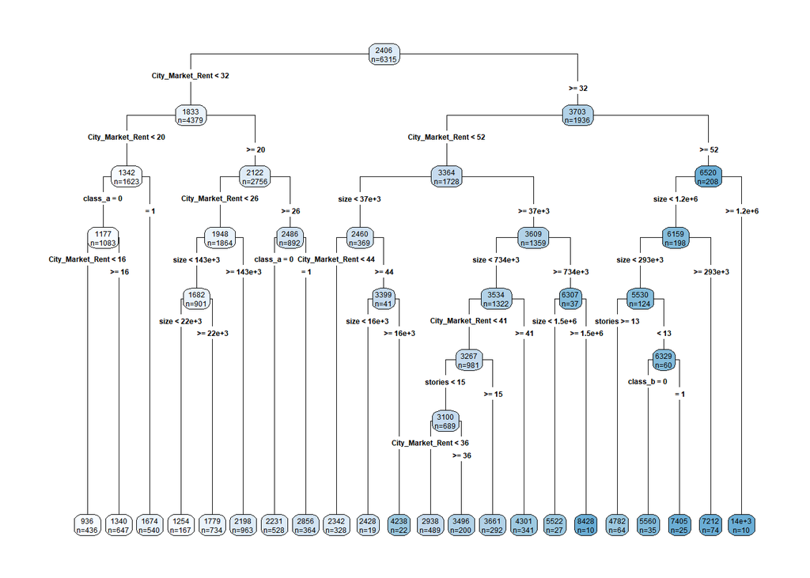

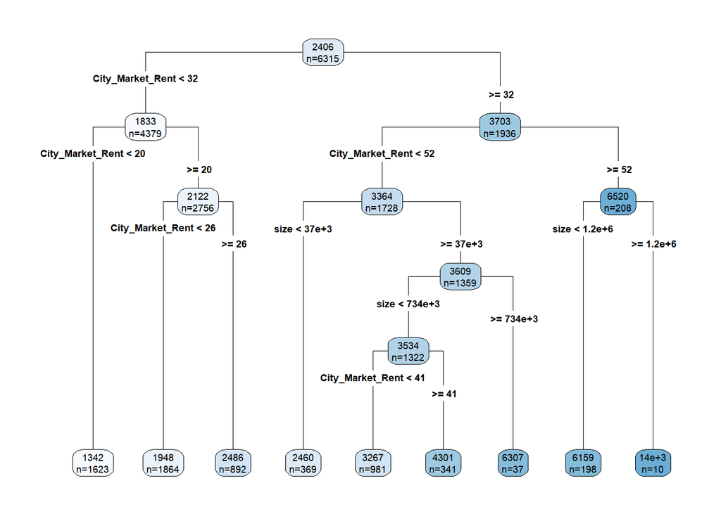

We used random forest and boosting and created more models for comparison

We tried the random forest model and the gradient-boosted model with the interactions I used earlier, but the tree models without them give me the lowest rmse model.

```
## Distribution not specified, assuming gaussian ...
```

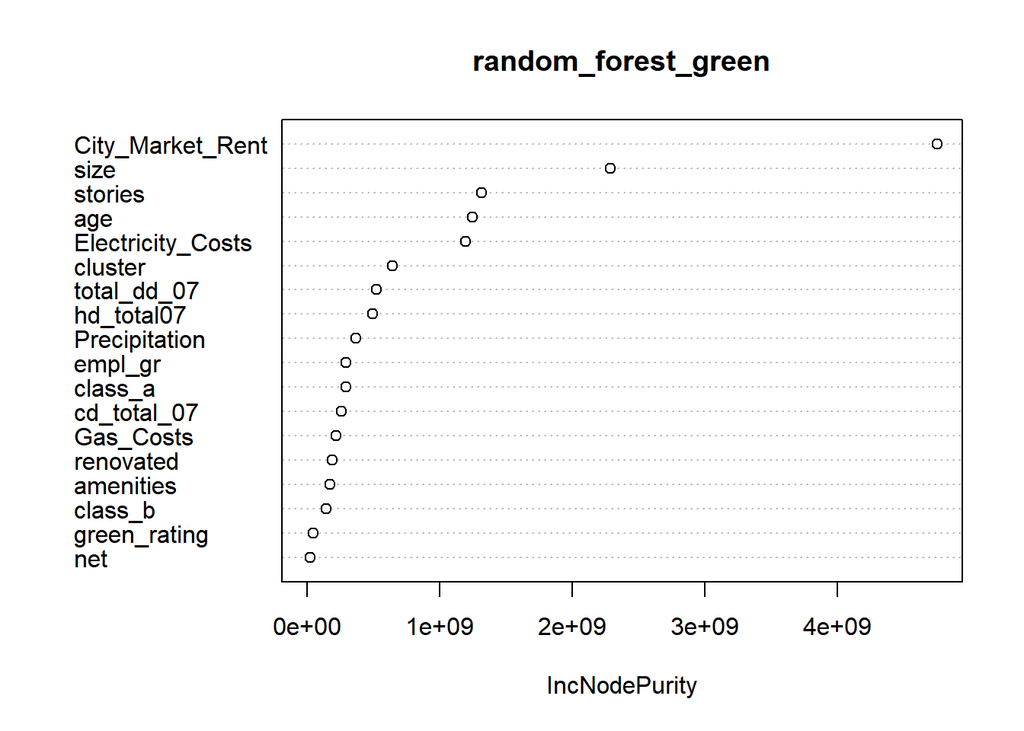

3. Conclusion

| Model | RMSE |
| --- | --- |
| Linear model | 1067.8691 |
| Improved linear model | 1062.0816 |
| Tree model | 1031.3779 |
| Pruned tree model | 1079.3572 |
| Random forest model | 732.6367 |
| Boosted model | 787.6833 |

## 4) Predictive model building: California housing